# Modeling

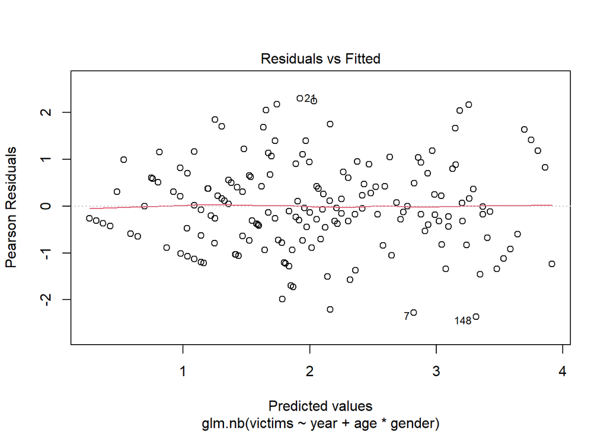

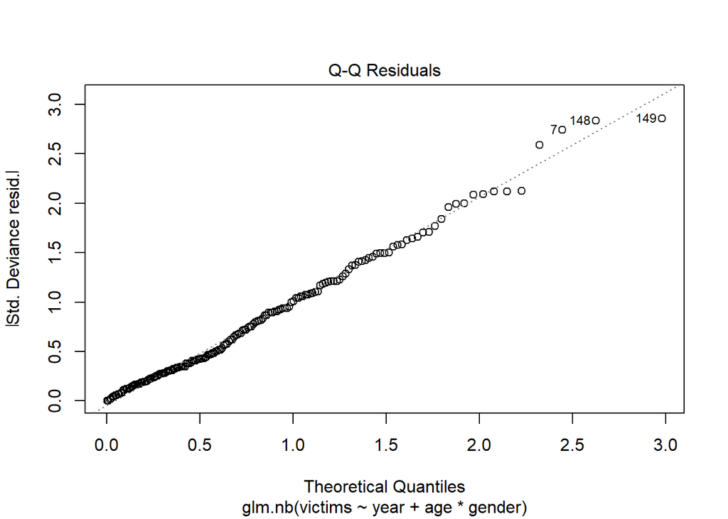

```r
plot(model_age_nb, which = 1:2)
```

```r
#Checking and plotting Deviance residuals and associated Quantile-Quantile (Q-Q) residuals
summary(residuals(model_age_nb, type = "deviance"))
```

```
##     Min.  1st Qu.   Median     Mean  3rd Qu.     Max.
## -2.68910 -0.67504 -0.06497 -0.05926  0.55197  2.03196
```

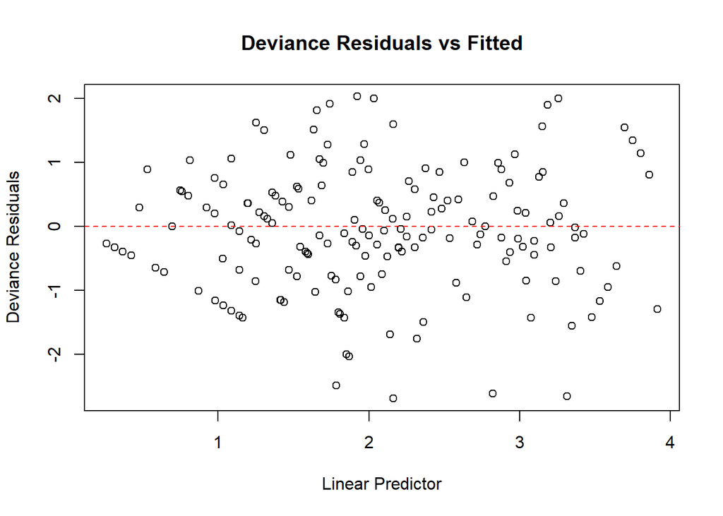

```r
dev_resid <- residuals(model_age_nb, type = "deviance")
plot(predict(model_age_nb, type = "link"), dev_resid,
     xlab = "Linear Predictor", ylab = "Deviance Residuals",
     main = "Deviance Residuals vs Fitted")
abline(h = 0, lty = 2, col = "red")
```

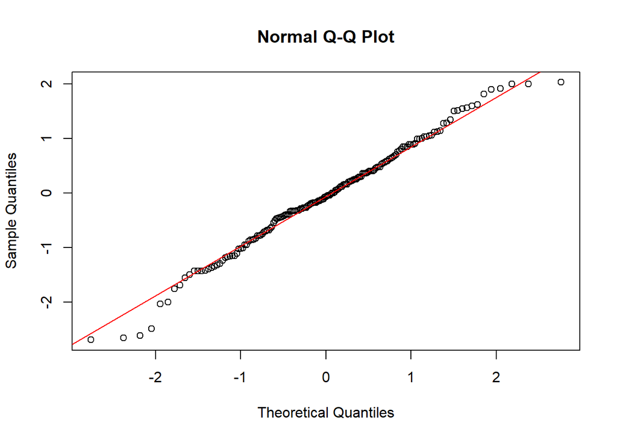

```r
qqnorm(dev_resid)
qqline(dev_resid, col = "red")
```

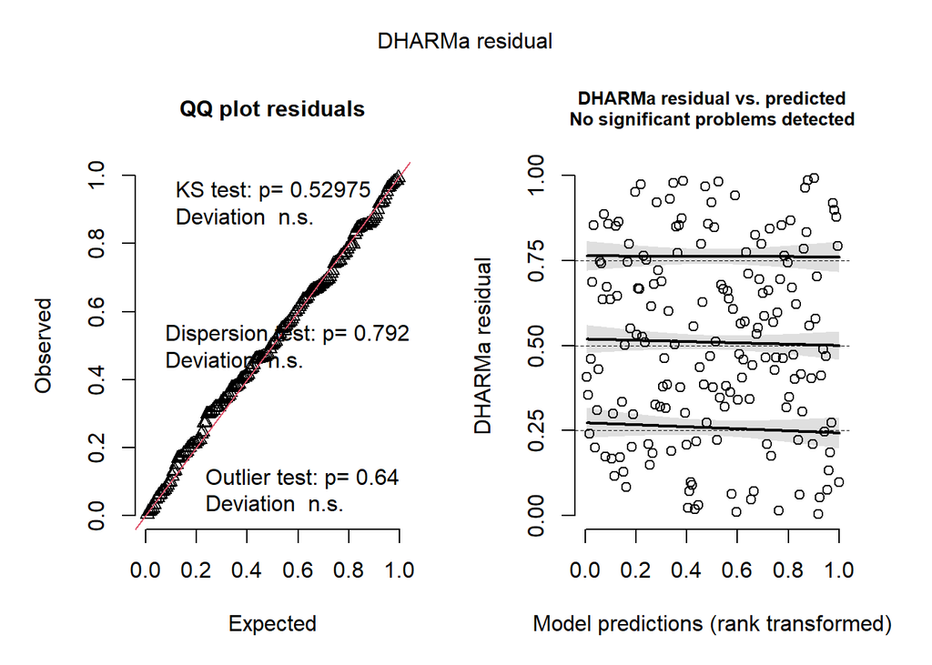

```r
#Plotting DHARMa Quantile residuals
plot(simulateResiduals(model_age_nb))
```

Pearson residuals suggests that the Negative Binomial model fits very well. Mean and median close to zero, symmetrical residual range (−2.37 to 2.30) within ±2±3, no obvious pattern or fan spread, and a residual deviance ration of 1.01 (158 on 156 df). Associated Q-Q plot did not identify and significant deviance, other then our previously found outliers (7,148,149).

Deviance residuals show nearly the same results. Mean and median close to zero, relatively symmetric residual range (-2.69 to 2.03) within ±3 suggesting no heavy tails on either end, and normality assumption is satified, and a residual deviance ratio of 1.01 (158 on 156 df). Associated Q-Q plot detected a slight deviation on the lower tail but was not significant. Deviance residuals also suggest that the Negative Binomial model fits the data well.

The large theta value (151) indicates the data is close to a Poisson distribution, but still slightly overdispersed relative to Poisson, justifying the use of a Negative Binomial model.

The Std. Error for theta (175) is larger than theta itself (151), which suggests some uncertainty in the dispersion estimate. However, the DHARMa dispersion test (p = 0.79) directly confirms that this does not lead to practical problems in the residuals.

Even though the AIC value for the NB model is higher then the Poisson model by 1.07, however, if AIC values are within 2 units of each other they are considered to have approximately the same performance.

```r
#Running AVOVA test on all three df_age models
anova(model_age_gaussian)
```

```
## Analysis of Deviance Table
##
## Model: gaussian, link: identity
##
## Response: Log_victims
##
## Terms added sequentially (first to last)
##
##
##            Df Deviance Resid. Df Resid. Dev        F    Pr(>F)
## NULL                         172    169.131
## year        1    6.246       171    162.886  31.2996 9.688e-08 ***
## age         7   84.218       164     78.667  60.2916 < 2.2e-16 ***
## gender      1   40.604       163     38.063 203.4784 < 2.2e-16 ***
## age:gender  7    6.933       156     31.130   4.9636 4.310e-05 ***
## ---
## Signif. codes:  0 '***' 0.001 '**' 0.01 '*' 0.05 '.' 0.1 ' ' 1
```

```r
anova(model_age_poisson)
```

```
## Analysis of Deviance Table
##
## Model: poisson, link: log
##
## Response: victims
##
## Terms added sequentially (first to last)
##
##
##            Df Deviance Resid. Df Resid. Dev  Pr(>Chi)
## NULL                         172    1502.92
## year        1    58.19       171    1444.73 2.379e-14 ***
## age         7   793.85       164     650.89 < 2.2e-16 ***
## gender      1   455.39       163     195.49 < 2.2e-16 ***
## age:gender  7    24.45       156     171.05 0.0009504 ***
## ---
## Signif. codes:  0 '***' 0.001 '**' 0.01 '*' 0.05 '.' 0.1 ' ' 1
```

```r
anova(model_age_nb)
```

```
## Analysis of Deviance Table
##
## Model: Negative Binomial(150.5117), link: log
##
## Response: victims
##
## Terms added sequentially (first to last)
##
##
##            Df Deviance Resid. Df Resid. Dev  Pr(>Chi)
## NULL                         172    1381.74
## year        1    54.22       171    1327.52 1.791e-13 ***
## age         7   736.73       164     590.79 < 2.2e-16 ***
## gender      1   409.20       163     181.58 < 2.2e-16 ***
## age:gender  7    23.58       156     158.00  0.001349 **
## ---
## Signif. codes:  0 '***' 0.001 '**' 0.01 '*' 0.05 '.' 0.1 ' ' 1
```

Results:

The residual deviance of the Gaussian model (residual deviance = 31.13 on 156 degrees of freedom) indicates under-dispersion which violates the Gaussian assumption of constant variance. While all terms and the interaction term of the Gaussian model were found to be significant, the log transformation did not fully correct the distributional problems inherent to count data.

Inversely, the residual deviance of the Poisson model (residual deviance = 171.05 on 156 degrees of freedom) indicates mild over-dispersion which violates the Poisson assumption that mean and variance are equal. Over-dispersion of any magnitude leads to underestimated standard errors and artificially small p-values. This means that even though the Poisson model found all terms and the interaction to be statistically significant, it is likely that the significance if being inflated due to over-dispersion.

The Negative Binomial model has the best overall goodness-of-fit (residual deviance = 158.00 on 156 degrees of freedom) indicating a near perfect fit. The dispersion parameter (θ = 150.51) is large suggesting a modest amount of over-dispersion, thus warranting the use of the Negative Binomial model to successfully accommodate for over-dispersion. The Negative Binomial regression indicates that all terms (year, age, gender, and the age × gender interaction) are statistically significant predictors of victim counts. The significance of the interaction (χ² = 23.58, p = 0.0013) indicates that the effect of gender on victimization varies significantly across age groups. All three models suggest that there is a significant interaction between age and gender regarding homicide victimization. For the Negative Binomial model, the interaction between age and gender has a statistically significant p-value (p = 0.00135). It was found that males experience higher rates of victimization across all age groups. However, the discrepancy between male and female victimization was not uniform between age groups. For males, the results indicate that victimization increases sharply from youth into adulthood, peaking in middle adulthood (30-39), then declines. For females, victimization increases more modestly with age with a smaller peak in middle adulthood (30-39), then declines as well. The discrepancy between male and female victimization is largest in this middle adulthood group and smallest among the youth and elderly groups.

Gaussian Model: F scores above 1 demonstrate that the group means differ, with higher values indicating stronger differences.

```r
model_age_gaussian2 <- aov(Log_victims ~ age * gender, data = df_age)
tukey_age_gaussian <- TukeyHSD(model_age_gaussian2)
print(tukey_age_gaussian)
```

```
##   Tukey multiple comparisons of means
##     95% family-wise confidence level
##
## Fit: aov(formula = Log_victims ~ age * gender, data = df_age)
##
## $age
##                                         diff          lwr         upr     p adj
## 12 to 17 years-0 to 11 years      0.27049978 -0.186202405  0.72720196 0.6077382
## 18 to 24 years-0 to 11 years      1.46627852  1.014918062  1.91763897 0.0000000
## 25 to 29 years-0 to 11 years      1.30464433  0.853283871  1.75600478 0.0000000
## 30 to 39 years-0 to 11 years      1.92034936  1.468988908  2.37170982 0.0000000
## 40 to 49 years-0 to 11 years      1.29436620  0.843005744  1.74572665 0.0000000
## 50 to 59 years-0 to 11 years      0.74850643  0.285999590  1.21101326 0.0000465
## 60 years and over-0 to 11 years  -0.07583084 -0.527191292  0.37552962 0.9995658
## 18 to 24 years-12 to 17 years     1.19577874  0.739076552  1.65248092 0.0000000
```

[output cut: 268 more lines]

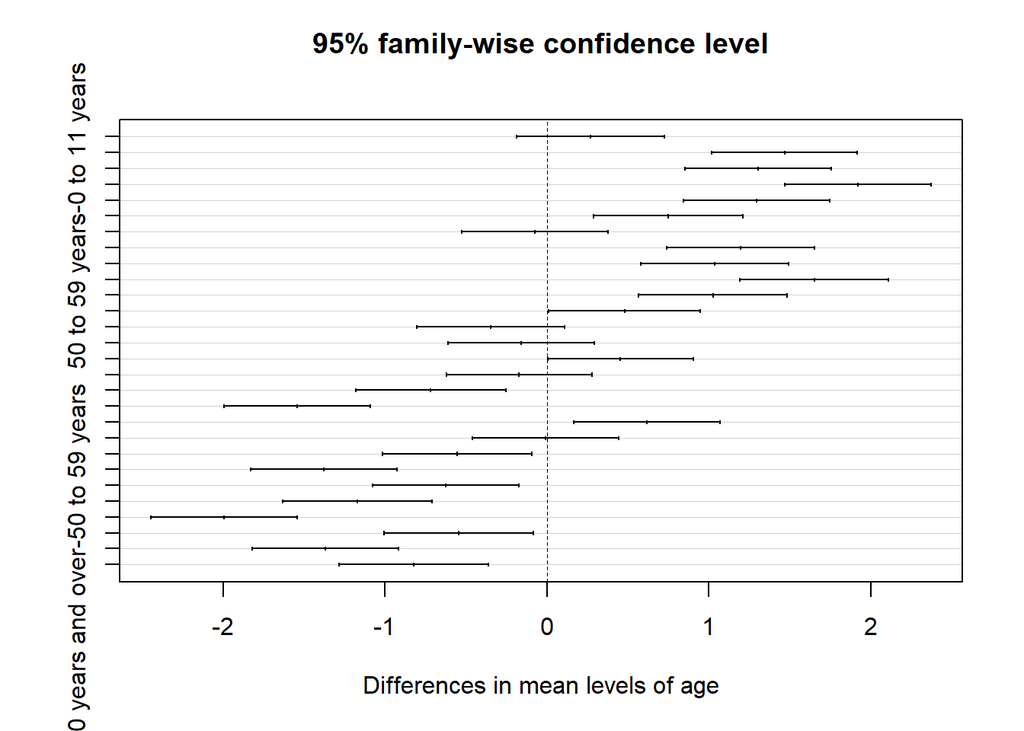

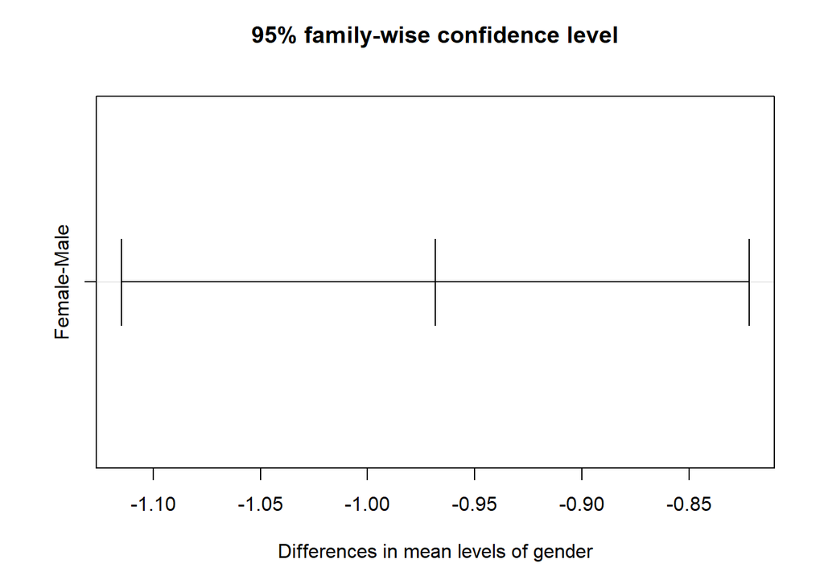

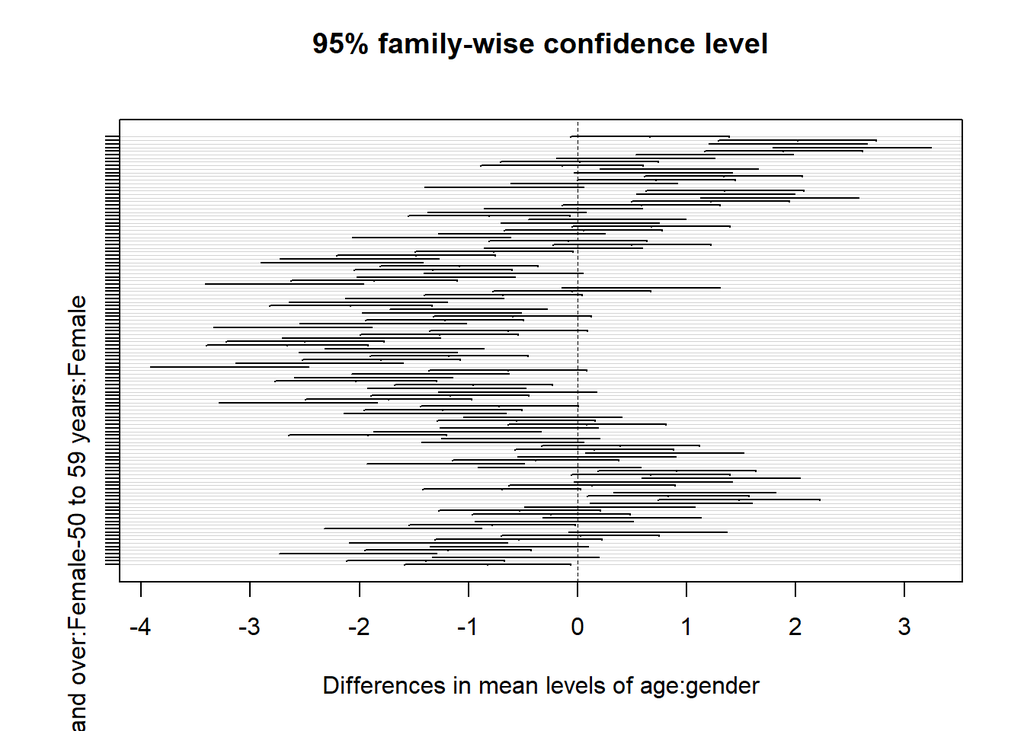

```r
plot(tukey_age_gaussian)
```

Regarding gender differences, the female-male mean group difference (averaged across age groups) was -0.968 with an adjusted p value of 0, indicating a significant negative difference. Particularly, females were found to have significantly lower Log_victim counts then males.

Regarding the interaction, within most age groups males tended to have higher means then females. Among males, means peaked at 30-39. When compared with our baseline group (male:0-11) with males:30-39, the mean group difference was +2.519 with an adjusted p value of 0, indicating a highly significant positive difference. For females, means also peaked in the 30-39 age group. When comparing females:30-39 to the baseline group (male:0-11) we see a mean group difference of +1.343 and an adjusted p value of 0.0000001. This significant positive difference indicates that Log_victims means are significantly higher among the female:30-39 group. Comparing the female:30-39 group with the female:60+ group we see a mean group difference of -2.012 with an adjusted p value of 0.000001, indicating significant negative difference, and a significantly lower Log_victims mean among the female:60+ group.

The distribution of age group means is broadly similar between genders, both rising with age, peaking from 30-39, then dropping with age, only the means for males are markedly higher then they are for females.

```r
model_age_poisson2 <- aov(victims ~ age * gender, data = df_age)
tukey_age_poisson <- TukeyHSD(model_age_poisson2)
print(tukey_age_poisson)
```

```
##   Tukey multiple comparisons of means
##     95% family-wise confidence level
##
## Fit: aov(formula = victims ~ age * gender, data = df_age)
##
## $age
##                                          diff        lwr         upr     p adj
## 12 to 17 years-0 to 11 years       1.16883117  -3.299215   5.6368771 0.9927095
## 18 to 24 years-0 to 11 years      12.36363636   7.947850  16.7794226 0.0000000
## 25 to 29 years-0 to 11 years      11.22727273   6.811486  15.6430590 0.0000000
## 30 to 39 years-0 to 11 years      21.86363636  17.447850  26.2794226 0.0000000
## 40 to 49 years-0 to 11 years       9.90909091   5.493305  14.3248772 0.0000000
## 50 to 59 years-0 to 11 years       4.30454545  -0.220289   8.8293799 0.0749426
## 60 years and over-0 to 11 years    0.09090909  -4.324877   4.5066953 1.0000000
## 18 to 24 years-12 to 17 years     11.19480519   6.726759  15.6628511 0.0000000
```

[output cut: 268 more lines]

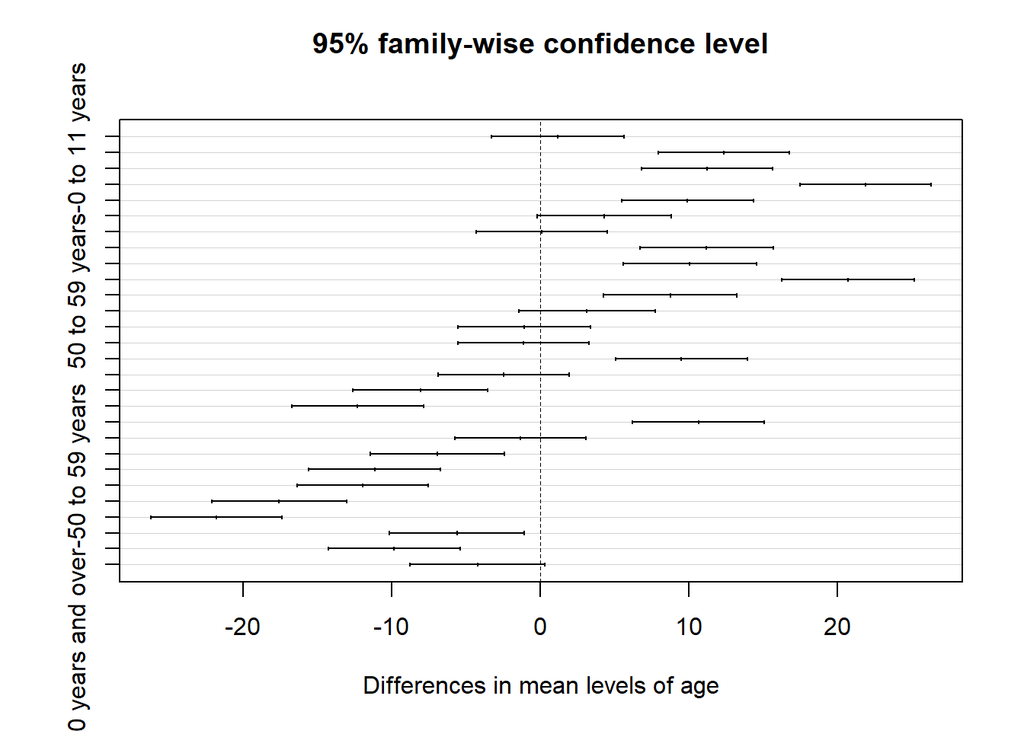

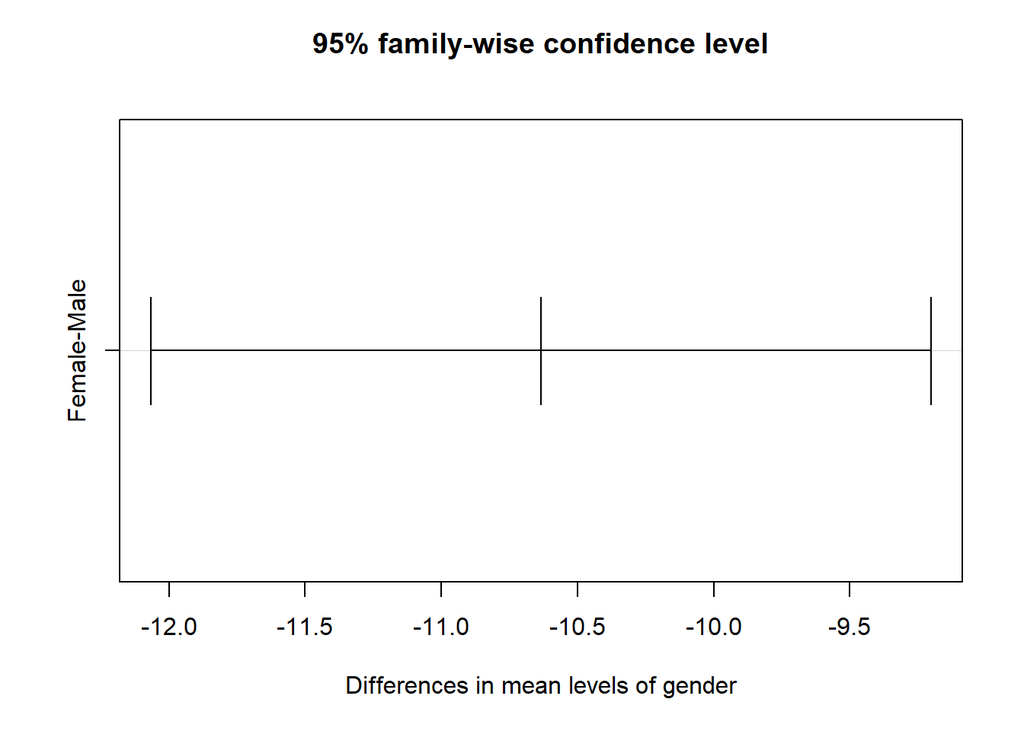

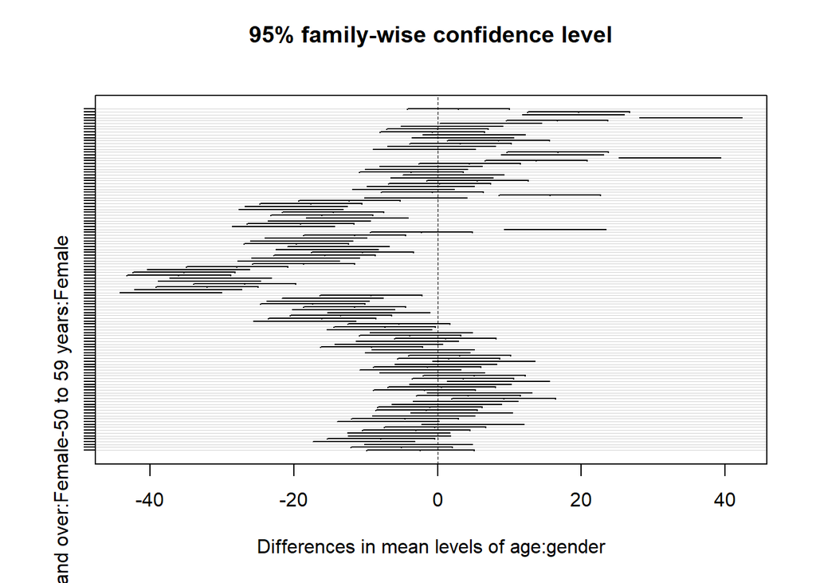

```r
plot(tukey_age_poisson)
```

Females were found to have significantly fewer victims the males (averaged across age groups) with a mean group difference of -10.6 and an adjusted p value of 0, indicating a significant negative difference.

Males:30–39 were found to have have dramatically higher means than every other combination. Comparing our male peak (30-39) with the baseline group (males:0-11), we see a mean group difference of 3.527273e+01 (35.273) with an adjusted p value of 0 (significant). The male:18-24 and male:25-29 were also shown to have significantly higher means then most groups. When comparing the baseline group and males:18-24 we see a mean group difference of 1.963636e+01 (19.636) and an adjusted p value of 0. Similarly, comparing the baseline to males:24-29 shows a mean group difference of 1.890909e+01 (18.89) and an adjusted p value of 0. Female means also peaked at the 30-39 age group, however female peak means were found to be significantly smaller then male peak means, with a mean group difference of -2.681818e+01 (-26.818) and an adjusted p value of 0. Females were also shown to have much smaller differences between age groups then males.For both males and females the 0-11 and 60+ age groups stayed consistently low.

Gender is a strong predictor as males are associated with comparatively more victimization than Females, regardless of age. The main effect of gender was significant (p < 0.001), with males averaging 10.6 more victims than females. Age is also a strong predictor with the 30–39 group showing the highest means and the 0-11 and 60+ groups showing the lowest means. The interaction between gender and age group was found to be significant, as it is indicated that gender differences in mean victim counts was much more prominent among males.

```r
model_age_nb2 <- aov(victims ~ age * gender, data = df_age)
tukey_age_nb <- TukeyHSD(model_age_nb2)
print(tukey_age_nb)
```

```
##   Tukey multiple comparisons of means
##     95% family-wise confidence level
##
## Fit: aov(formula = victims ~ age * gender, data = df_age)
##
## $age
##                                          diff        lwr         upr     p adj
## 12 to 17 years-0 to 11 years       1.16883117  -3.299215   5.6368771 0.9927095
## 18 to 24 years-0 to 11 years      12.36363636   7.947850  16.7794226 0.0000000
## 25 to 29 years-0 to 11 years      11.22727273   6.811486  15.6430590 0.0000000
## 30 to 39 years-0 to 11 years      21.86363636  17.447850  26.2794226 0.0000000
## 40 to 49 years-0 to 11 years       9.90909091   5.493305  14.3248772 0.0000000
## 50 to 59 years-0 to 11 years       4.30454545  -0.220289   8.8293799 0.0749426
## 60 years and over-0 to 11 years    0.09090909  -4.324877   4.5066953 1.0000000
## 18 to 24 years-12 to 17 years     11.19480519   6.726759  15.6628511 0.0000000
```

[output cut: 268 more lines]

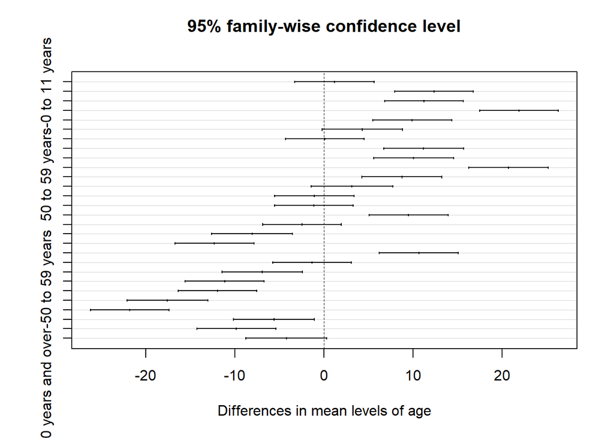

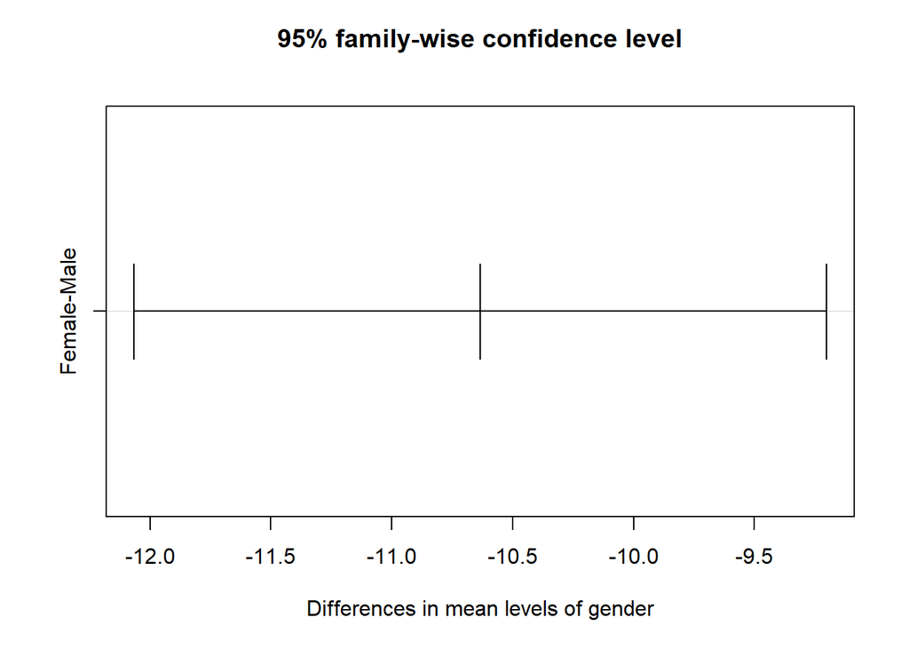

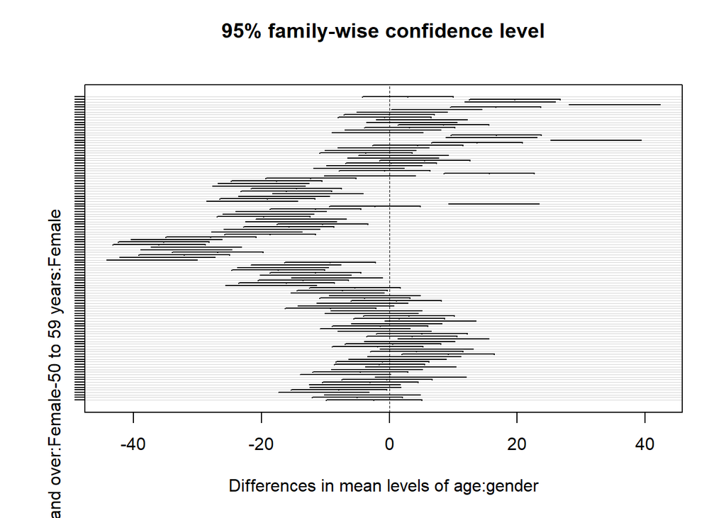

```r
plot(tukey_age_nb)
```

Tukey HSD results for the Negative Binomial model are identical to the Tukey HSD results for the Poisson model above.